# Contact Experiment Data Analysis

First Step is to load the necessary package, If you dont have them just install them. For jjstatsplot you need to install it remotely. Just remove the dash and press enter. Then Press 3 (none package to be updated). ?group_by()

```r
#remotes::install_github("sbalci/jjstatsplot") #Press 3 !!!!! i.e., installing/Updating none package!
library(jmv)
library(datasets)
library(plyr)
library(readr)
library(dataframes2xls)
library(data.table)
library(plyr)
library(ggstatsplot)
library(jjstatsplot)
library(lme4)
library(lmerTest)
library(ggplot2)
library(rstatix)
library(coin)
library(ARTool)
library(ggpubr)
library(tidyverse)
library(dplyr)
library("afex")
library("emmeans")
library("multcomp")
library(tinytex)
library(rsconnect)
library(shiny)
```

Import and merge all the csv files (x.csv where x = ID) of the folder. Note, that the ID is has already been added as column

Discard first X trials per interpenetration feedback condition and then create a summary table for each participant. You need to define **nrTrialsPerBlockToRemove**.

```r
data$Part <- as.factor(data$Block < 4)
levels(data$Part)
```

```
## [1] "FALSE" "TRUE"
```

```r
data$Part <- factor(data$Part,levels = c("TRUE","FALSE"),
                  labels = c("Part 1","Part 2"))

nrTrialsPerBlockToRemove <- 1
#trialsToRemove <- seq(from = 1, to = nrTrialsPerBlockToRemove)

  data <-  data %>%
    group_by(ID, Part, InterpenetrationFeedback, FullyShaded) %>% # I have added here the fully shaded
    slice(nrTrialsPerBlockToRemove+1:n())
  # to double check we are discarding the right rows
  #print(data[[i]]$Trial)

 # This df will be used to create the subsets for 1st part and 2nd part of the experiment.

data$InterpenetrationFeedback  <- as.factor(data$InterpenetrationFeedback)
data$FullyShaded <- as.factor(data$FullyShaded)
```

```r
ParsiDF <- data


# Exclude the IDs which produced the extreme values (i.e., = or > 3 coefficients from the mean)
ParsiDF$ID[ParsiDF$ID == 9] <- NA
ParsiDF$ID[ParsiDF$ID == 17] <- NA
ParsiDF$ID[ParsiDF$ID == 20] <- NA

ParsiDF <- na.omit(ParsiDF)

ParsiDF <- aggregate(. ~ ID + Age + Gender + InterpenetrationFeedback + Part, ParsiDF, mean)

#Before Conversion to logarithms (showing the abnormal distribution)
shapiro_test(ParsiDF$MaxInterpenetration)
```

| variable | statistic | p.value |
| --- | --- | --- |
| ParsiDF$MaxInterpenetration | 0.9370057 | 9.455934e-07 |

```r
shapiro_test(ParsiDF$AverageInterpenetration)
```

| variable | statistic | p.value |
| --- | --- | --- |
| ParsiDF$AverageInterpenetration | 0.9363698 | 8.438468e-07 |

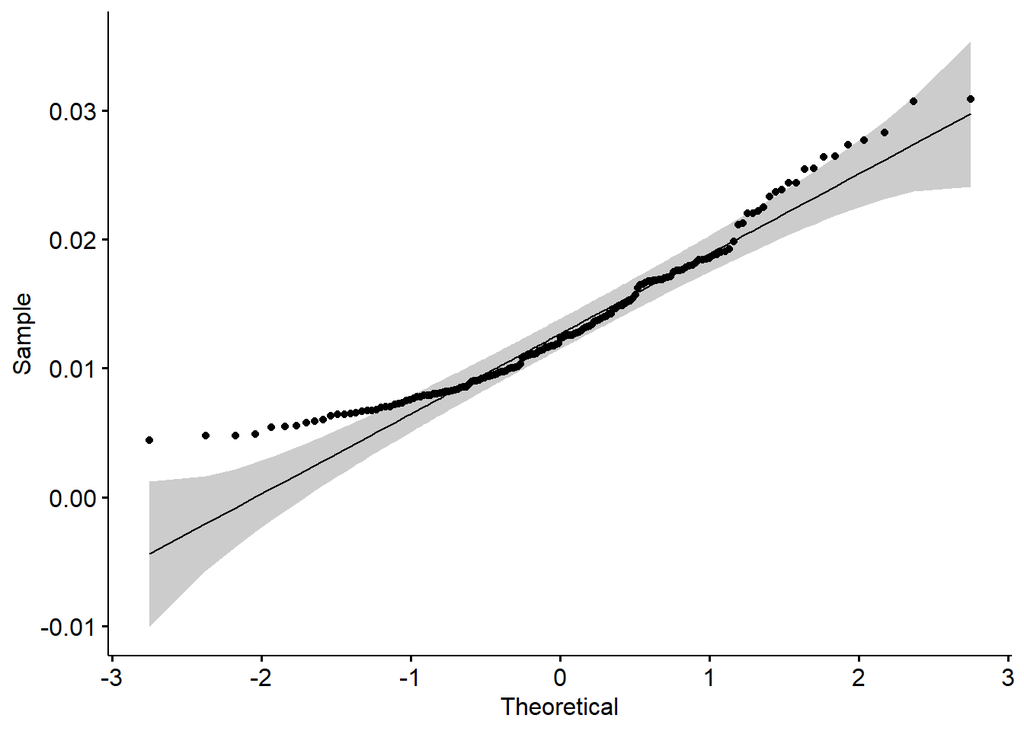

```r
ggqqplot(ParsiDF$MaxInterpenetration)
```

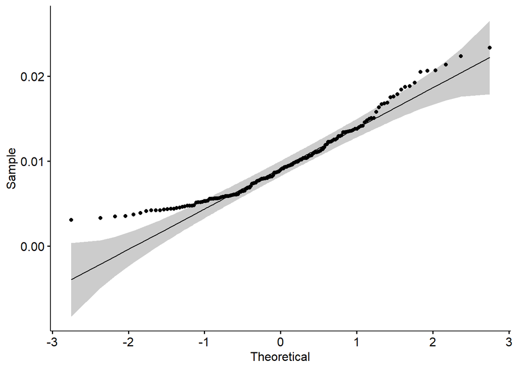

```r
ggqqplot(ParsiDF$AverageInterpenetration)
```

```r
ParsiDF %>%
  group_by(InterpenetrationFeedback, Part) %>%
  shapiro_test(MaxInterpenetration)
```

| InterpenetrationFeedback | Part | variable | statistic | p |
| --- | --- | --- | --- | --- |
| Both | Part 1 | MaxInterpenetration | 0.9463698 | 0.290340459 |
| Both | Part 2 | MaxInterpenetration | 0.8336128 | 0.002246291 |
| Electrotactile | Part 1 | MaxInterpenetration | 0.9674758 | 0.676776433 |
| Electrotactile | Part 2 | MaxInterpenetration | 0.8590639 | 0.006110260 |
| NoFeedback | Part 1 | MaxInterpenetration | 0.9694181 | 0.720117306 |
| NoFeedback | Part 2 | MaxInterpenetration | 0.9767405 | 0.872128294 |
| Visual | Part 1 | MaxInterpenetration | 0.8595117 | 0.006222341 |
| Visual | Part 2 | MaxInterpenetration | 0.8984690 | 0.032684820 |

```r
ParsiDF %>%
  group_by(InterpenetrationFeedback, Part) %>%
  shapiro_test(AverageInterpenetration)
```

| InterpenetrationFeedback | Part | variable | statistic | p |
| --- | --- | --- | --- | --- |
| Both | Part 1 | AverageInterpenetration | 0.9471955 | 0.301176358 |
| Both | Part 2 | AverageInterpenetration | 0.8270140 | 0.001750387 |
| Electrotactile | Part 1 | AverageInterpenetration | 0.9636280 | 0.591983751 |
| Electrotactile | Part 2 | AverageInterpenetration | 0.8768082 | 0.012752470 |
| NoFeedback | Part 1 | AverageInterpenetration | 0.9638882 | 0.597610313 |
| NoFeedback | Part 2 | AverageInterpenetration | 0.9549130 | 0.420117907 |
| Visual | Part 1 | AverageInterpenetration | 0.8511819 | 0.004451891 |
| Visual | Part 2 | AverageInterpenetration | 0.9138840 | 0.065545152 |

```r
#After Conversion of the performance variables into logs (Normal Distribution)
ParsiDF$MaxInterpenetration <- log(ParsiDF$MaxInterpenetration)

ParsiDF$AverageInterpenetration <- log(ParsiDF$AverageInterpenetration)

shapiro_test(ParsiDF$MaxInterpenetration)
```

| variable | statistic | p.value |
| --- | --- | --- |
| ParsiDF$MaxInterpenetration | 0.9876969 | 0.1490966 |

```r
shapiro_test(ParsiDF$AverageInterpenetration)
```

| variable | statistic | p.value |
| --- | --- | --- |
| ParsiDF$AverageInterpenetration | 0.9858611 | 0.08731612 |

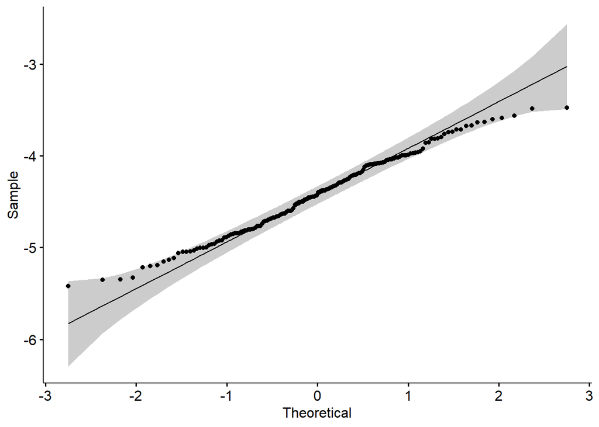

```r
ggqqplot(ParsiDF$MaxInterpenetration)
```

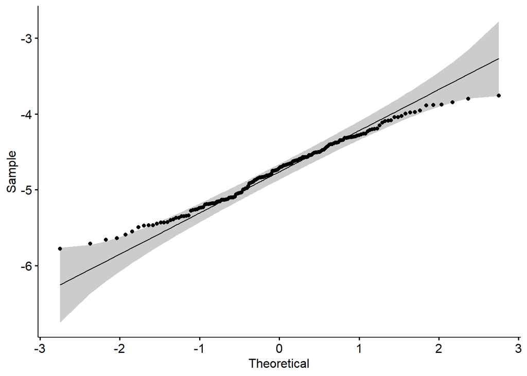

```r
ggqqplot(ParsiDF$AverageInterpenetration)
```

```r
#Let's check the assumption for each interpenetration feedback and shade condition
ParsiDF %>%
  group_by(InterpenetrationFeedback, Part) %>%
  shapiro_test(MaxInterpenetration)
```

| InterpenetrationFeedback | Part | variable | statistic | p |
| --- | --- | --- | --- | --- |
| Both | Part 1 | MaxInterpenetration | 0.9868279 | 0.9888746 |
| Both | Part 2 | MaxInterpenetration | 0.9661039 | 0.6462359 |
| Electrotactile | Part 1 | MaxInterpenetration | 0.9308313 | 0.1430371 |
| Electrotactile | Part 2 | MaxInterpenetration | 0.9745812 | 0.8307246 |
| NoFeedback | Part 1 | MaxInterpenetration | 0.9575452 | 0.4681252 |
| NoFeedback | Part 2 | MaxInterpenetration | 0.9507758 | 0.3523142 |
| Visual | Part 1 | MaxInterpenetration | 0.9631842 | 0.5824357 |
| Visual | Part 2 | MaxInterpenetration | 0.9755908 | 0.8505899 |

```r
ParsiDF %>%
  group_by(InterpenetrationFeedback, Part) %>%
  shapiro_test(AverageInterpenetration)
```

| InterpenetrationFeedback | Part | variable | statistic | p |
| --- | --- | --- | --- | --- |
| Both | Part 1 | AverageInterpenetration | 0.9757532 | 0.8537070 |
| Both | Part 2 | AverageInterpenetration | 0.9703017 | 0.7397138 |
| Electrotactile | Part 1 | AverageInterpenetration | 0.9535159 | 0.3961648 |
| Electrotactile | Part 2 | AverageInterpenetration | 0.9786997 | 0.9056434 |
| NoFeedback | Part 1 | AverageInterpenetration | 0.9556940 | 0.4339728 |
| NoFeedback | Part 2 | AverageInterpenetration | 0.9767880 | 0.8729898 |
| Visual | Part 1 | AverageInterpenetration | 0.9553767 | 0.4283032 |
| Visual | Part 2 | AverageInterpenetration | 0.9639963 | 0.5999528 |

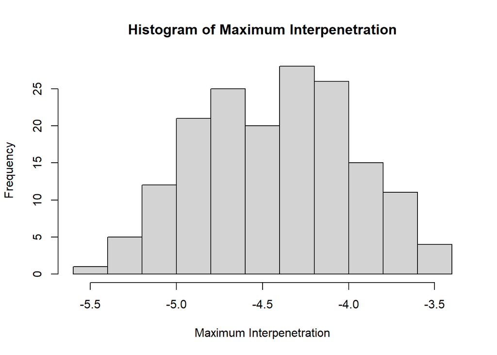

```r
hist(ParsiDF$MaxInterpenetration,main = paste("Histogram of Maximum Interpenetration") , xlab = "Maximum Interpenetration")
```

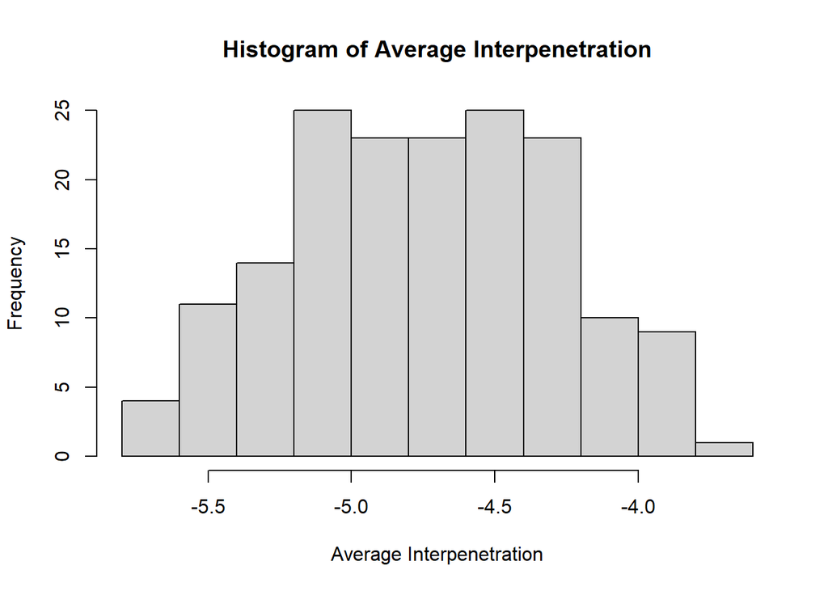

```r
hist(ParsiDF$AverageInterpenetration, main = paste("Histogram of Average Interpenetration") , xlab = "Average Interpenetration")
```

Let’s visualize the data per interpenetration feedback and/or part of the experiment (part 1 & part 2).

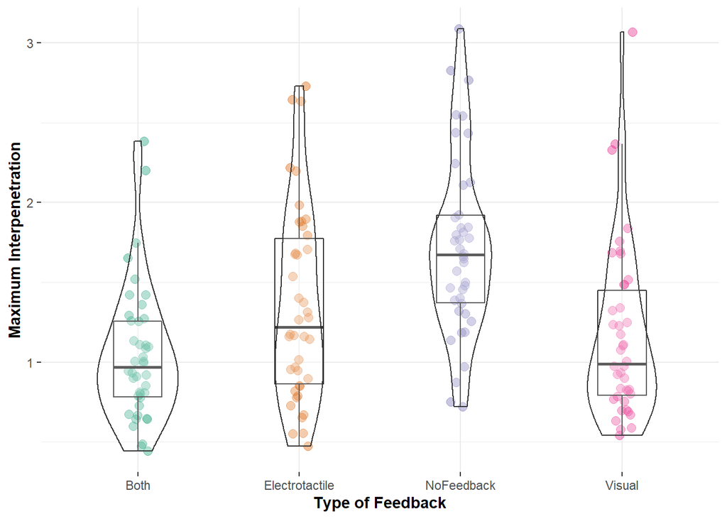

```r
ParsiDFplots <- data # A dataframe just for the plots, so we show everything in real numbers and in centimeters!
ParsiDFplots$ID[ParsiDFplots$ID == 9] <- NA
ParsiDFplots$ID[ParsiDFplots$ID == 17] <- NA
ParsiDFplots$ID[ParsiDFplots$ID == 20] <- NA
ParsiDFplots <- na.omit(ParsiDFplots)
ParsiDFplots <- aggregate(. ~ ID + Age + Gender + InterpenetrationFeedback + Part, ParsiDFplots, mean)

ParsiDFplots$AverageInterpenetration <-100 * ParsiDFplots$AverageInterpenetration #Converting meters to centimeters
ParsiDFplots$MaxInterpenetration <- 100 * ParsiDFplots$MaxInterpenetration #Converting meters to centimeters

p1 <- ggstatsplot::ggbetweenstats(
  data = ParsiDFplots,
  x = "InterpenetrationFeedback", #Indepedent Variable
  y = "MaxInterpenetration", # Depedent Variable
  grouping.var = "Part", # 2nd IV
  type = "p", # parametric test i.e., p values
  pairwise.comparisons = FALSE, #compute pairwise comparisons
  pairwise.display = "significant", # show only the significant ones
  p.adjust.method = "bonferroni", # correction of p-value
  effsize.type = "unbiased", # Calculates the Hedge's g for t tests and the partial Omega for ANOVA
  results.subtitle = FALSE,
  xlab = "Type of Feedback", #label of X axis
  ylab = "Maximum Interpenetration", #label of y axis
  sample.size.label = FALSE,
  var.equal = TRUE, #Assuming Equal variances
  mean.plotting = FALSE,
  mean.ci = TRUE, #display the confidence interval of the mean
  paired = TRUE, #indicating that we have a within subject design
  title.text = "Interpenetration Box-Violin Plots",
  caption.text = "Note: Interpenetration distance is displayed in cm.",
  title.color = "black",
  caption.color = "black"
  )

p2 <- ggstatsplot::ggbetweenstats(
  data = ParsiDFplots,
  x = "InterpenetrationFeedback",
  y = "AverageInterpenetration",
  grouping.var = "Part",
  type = "p",
  pairwise.comparisons = FALSE,
  pairwise.display = "significant",
  p.adjust.method = "bonferroni",
  effsize.type = "unbiased",
  results.subtitle = FALSE,
  xlab = "Type of Feedback",
  ylab = "Average Interpenetration",
  sample.size.label = FALSE,
  var.equal = TRUE,
  mean.plotting = FALSE,
  mean.ci = TRUE,
  paired = TRUE,
  title.text = "Interpenetration Box-Violin Plots",
  caption.text = "Note: Interpenetration distance is displayed in cm.",
  title.color = "black",
  caption.color = "black"
)


# Replicating the above but this time we look on the effect of the type of feedback on the DVs in 1st and 2nd Part of the experiment individually
p3 <- ggstatsplot::grouped_ggbetweenstats(
  data = ParsiDFplots,
  x = "InterpenetrationFeedback",
  y = "MaxInterpenetration",
  grouping.var = "Part",
  type = "p",
  pairwise.comparisons = FALSE,
  pairwise.display = "significant",
  p.adjust.method = "bonferroni",
  effsize.type = "unbiased",
  results.subtitle = FALSE,
  xlab = "Type of Feedback",
  ylab = "Maximum Interpenetration",
  sample.size.label = FALSE,
  var.equal = TRUE,
  mean.plotting = FALSE,
  mean.ci = TRUE,
  paired = TRUE,
  title.text = "Interpenetration Box-Violin Plots",
  caption.text = "Note: Interpenetration distance is displayed in cm.",
  title.color = "black",
  caption.color = "black"
  )

p4 <- ggstatsplot::grouped_ggbetweenstats(
  data = ParsiDFplots,
  x = "InterpenetrationFeedback",
  y = "AverageInterpenetration",
  grouping.var = "Part",
  type = "p",
  pairwise.comparisons = FALSE,
  pairwise.display = "significant",
  p.adjust.method = "bonferroni",
  effsize.type = "unbiased",
  results.subtitle = FALSE,
  xlab = "Type of Feedback",
  ylab = "Average Interpenetration",
  sample.size.label = FALSE,
  var.equal = TRUE,
  mean.plotting = FALSE,
  mean.ci = TRUE,
  paired = TRUE,
  title.text = "Interpenetration Box-Violin Plots",
  caption.text = "Note: Interpenetration distance is displayed in cm.",
  title.color = "black",
  caption.color = "black"
)

# Lets check the effect of shaded condition on DVs
p5 <- ggstatsplot:: ggbetweenstats(
  data = ParsiDFplots,
  x = "Part",
  y = "MaxInterpenetration",
  grouping.var = "InterpenetrationFeedback",
  type = "p",
  pairwise.comparisons = FALSE,
  pairwise.display = "significant",
  p.adjust.method = "bonferroni",
  effsize.type = "unbiased",
  results.subtitle = FALSE,
  xlab = "Order",
  ylab = "Maximum Interpenetration",
  sample.size.label = FALSE,
  var.equal = TRUE,
  mean.plotting = FALSE,
  mean.ci = TRUE,
  paired = TRUE,
  title.text = "Interpenetration Box-Violin Plots",
  caption.text = "Note: Interpenetration distance is displayed in cm.",
  title.color = "black",
  caption.color = "black"
  )

p6 <- ggstatsplot::ggbetweenstats(
  data = ParsiDFplots,
  x = "Part",
  y = "AverageInterpenetration",
  grouping.var = "InterpenetrationFeedback",
  type = "p",
  pairwise.comparisons = FALSE,
  pairwise.display = "significant",
  p.adjust.method = "bonferroni",
  effsize.type = "unbiased",
  results.subtitle = FALSE,
  xlab = "Order",
  ylab = "Average Interpenetration",
  sample.size.label = FALSE,
  var.equal = TRUE,
  mean.plotting = FALSE,
  mean.ci = TRUE,
  paired = TRUE,
  title.text = "Interpenetration Box-Violin Plots",
  caption.text = "Note: Interpenetration distance is displayed in cm.",
  title.color = "black",
  caption.color = "black"
)

p7 <- ggstatsplot::grouped_ggbetweenstats(
  data = ParsiDFplots,
  x = "Part",
  y = "MaxInterpenetration",
  grouping.var = "InterpenetrationFeedback",
  type = "p",
  pairwise.comparisons = FALSE,
  pairwise.display = "significant",
  p.adjust.method = "bonferroni",
  effsize.type = "unbiased",
  results.subtitle = FALSE,
  xlab = "Order",
  ylab = "Maximum Interpenetration",
  sample.size.label = FALSE,
  var.equal = TRUE,
  mean.plotting = FALSE,
  mean.ci = TRUE,
  paired = TRUE,
  title.text = "Interpenetration Box-Violin Plots",
  caption.text = "Note: Interpenetration distance is displayed in cm.",
  title.color = "black",
  caption.color = "black")

p8 <- ggstatsplot::grouped_ggbetweenstats(
  data = ParsiDFplots,
  x = "Part",
  y = "AverageInterpenetration",
  grouping.var = "InterpenetrationFeedback",
  type = "p",
  pairwise.comparisons = FALSE,
  pairwise.display = "significant",
  p.adjust.method = "bonferroni",
  effsize.type = "unbiased",
  results.subtitle = FALSE,
  xlab = "Order",
  ylab = "Average Interpenetration",
  sample.size.label = FALSE,
  var.equal = TRUE,
  mean.plotting = FALSE,
  mean.ci = TRUE,
  paired = TRUE,
  title.text = "Interpenetration Box-Violin Plots",
  caption.text = "Note: Interpenetration distance is displayed in cm.",
  title.color = "black",
  caption.color = "black"
  )
p1
```

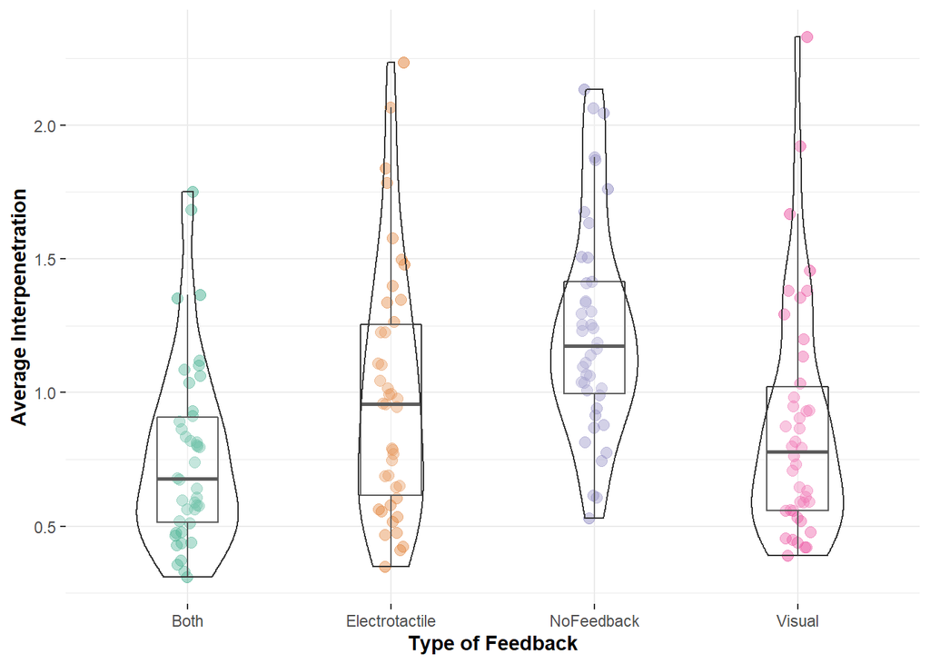

```r
p2
```

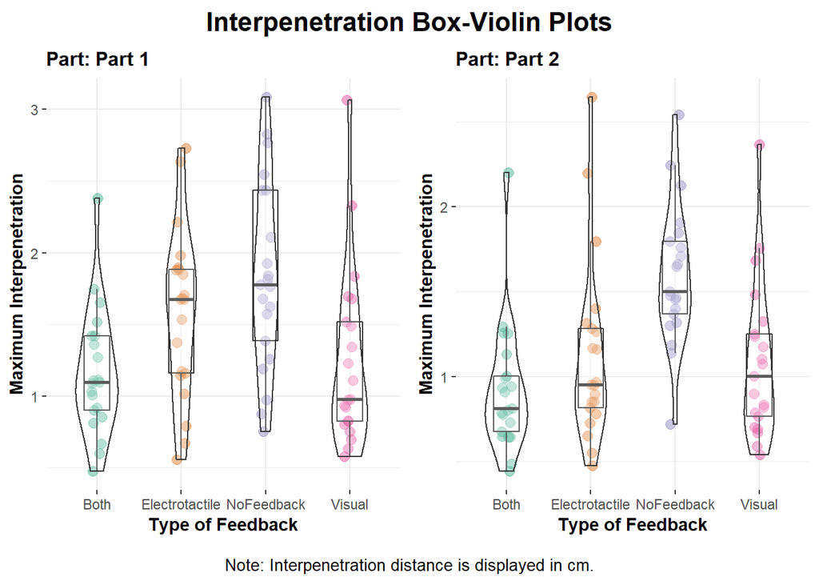

```r
p3
```

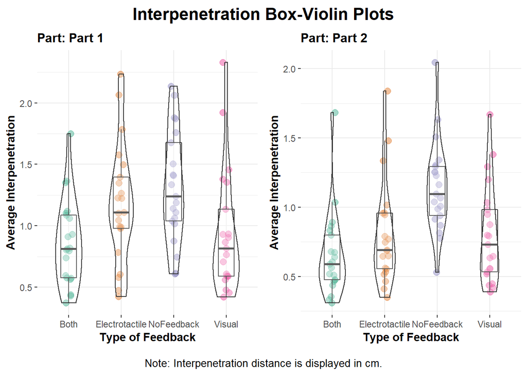

```r
p4
```

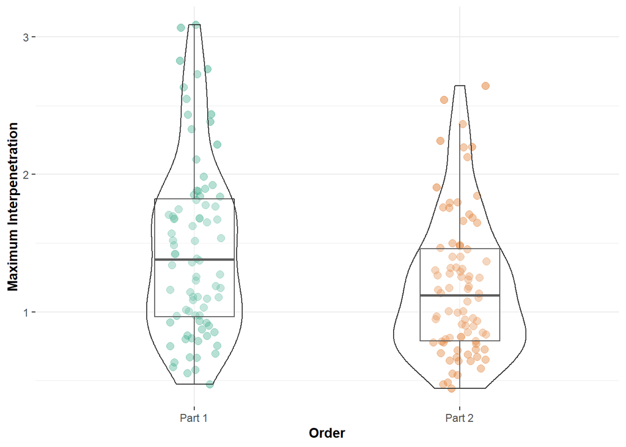

```r
p5
```

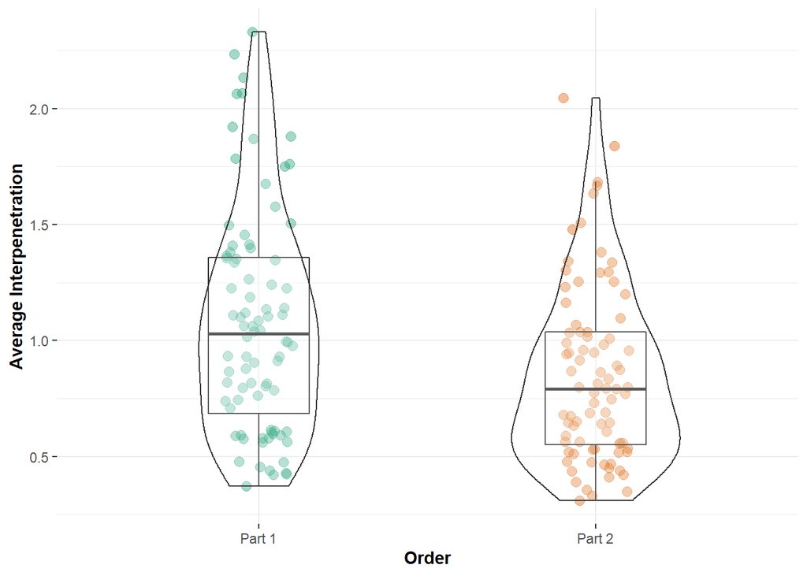

```r
p6
```

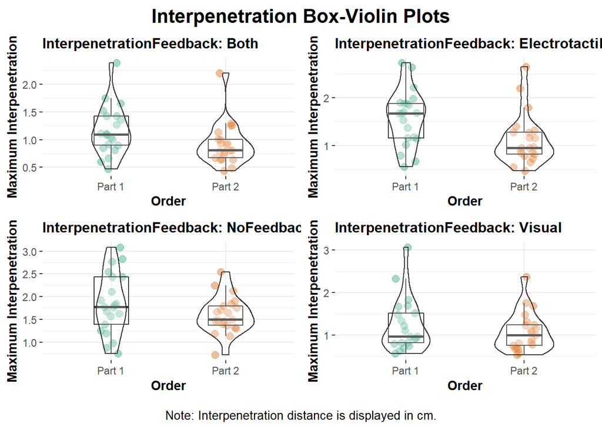

```r
p7
```

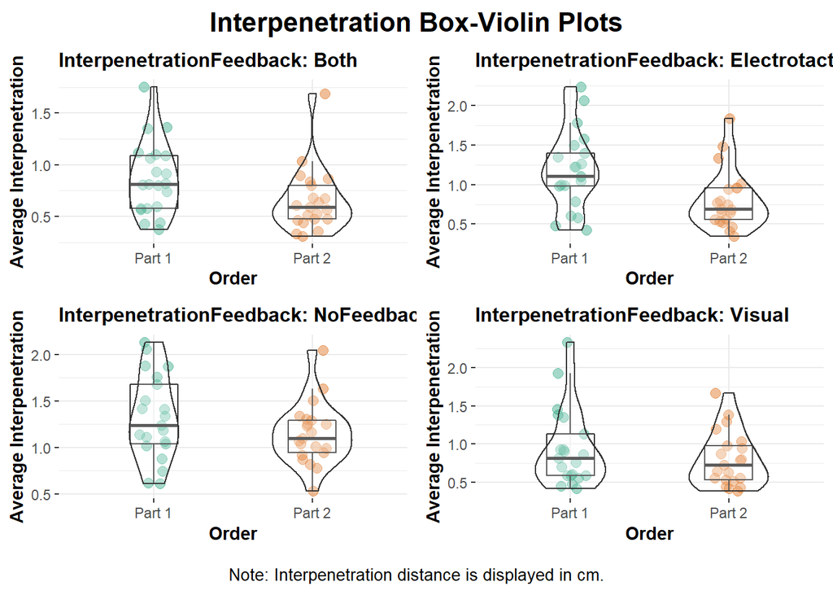

```r
p8
```

Let’s check the Two Way Repeated Measures ANOVA

```r
aMax <- aov_ez("ID", "MaxInterpenetration", ParsiDF,
             within = c("Part", "InterpenetrationFeedback"),
             anova_table = list(es = "pes"))

knitr::kable(nice(aMax$anova_table))
```

| Effect | df | MSE | F | pes | p.value |
| --- | --- | --- | --- | --- | --- |
| Part | 1, 20 | 0.06 | 29.43 *** | .595 | <.001 |
| InterpenetrationFeedback | 1.88, 37.52 | 0.12 | 28.36 *** | .586 | <.001 |
| Part:InterpenetrationFeedback | 2.06, 41.24 | 0.04 | 5.16 ** | .205 | .009 |

```r
aAv <- aov_ez("ID", "AverageInterpenetration", ParsiDF,
             within = c("Part", "InterpenetrationFeedback"),
             anova_table = list(es = "pes"))

knitr::kable(nice(aAv$anova_table))
```

| Effect | df | MSE | F | pes | p.value |
| --- | --- | --- | --- | --- | --- |
| Part | 1, 20 | 0.07 | 31.74 *** | .613 | <.001 |
| InterpenetrationFeedback | 1.97, 39.31 | 0.12 | 25.89 *** | .564 | <.001 |
| Part:InterpenetrationFeedback | 2.11, 42.21 | 0.04 | 5.72 ** | .222 | .006 |

The Effect Sizes of the above ANOVAs: 1) Max Interpenetration 2) Average Interpenetration

```r
effectsize::omega_squared(aMax, partial = TRUE, ci = 0.95)
```

| Parameter | Omega_Sq_partial | CI | CI_low | CI_high |
| --- | --- | --- | --- | --- |
| Part | 0.5637517 | 0.95 | 0.23872745 | 0.7392271 |
| InterpenetrationFeedback | 0.5618839 | 0.95 | 0.38039068 | 0.6754044 |
| Part:InterpenetrationFeedback | 0.1631799 | 0.95 | -0.01643713 | 0.3235300 |

```r
effectsize::omega_squared(aAv, partial = TRUE, ci = 0.95)
```

| Parameter | Omega_Sq_partial | CI | CI_low | CI_high |
| --- | --- | --- | --- | --- |
| Part | 0.5828593 | 0.95 | 0.263294698 | 0.7511861 |
| InterpenetrationFeedback | 0.5384726 | 0.95 | 0.350920524 | 0.6570499 |
| Part:InterpenetrationFeedback | 0.1811668 | 0.95 | -0.005020817 | 0.3423997 |

We can see that every type of feedback as well as the interrelationship with the part of the experiment have a large effect on DVs!!!!!!

Reference for interpreting Omega Squared Small effect: ω2 = 0.01; Medium effect: ω2 = 0.06; Large effect: ω2 = 0.14.

Let’s plot the main effects (Interpenetration Feedback OR Part of the experiment).

```
## NOTE: Results may be misleading due to involvement in interactions
```

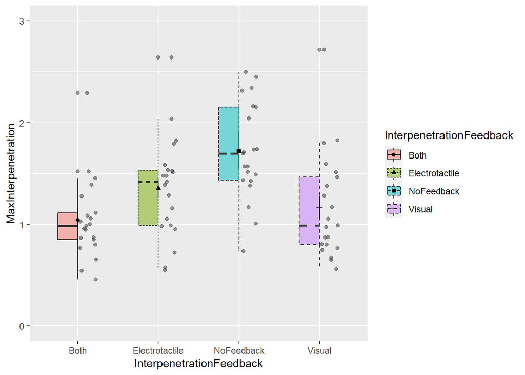

```r
# ANOVAs just for the plots
aMaxPlots <- aov_ez("ID", "MaxInterpenetration", ParsiDFplots,
             within = c("Part", "InterpenetrationFeedback"),
             anova_table = list(es = "pes"))

aAvPlots <- aov_ez("ID", "AverageInterpenetration", ParsiDFplots,
             within = c("Part", "InterpenetrationFeedback"),
             anova_table = list(es = "pes"))

#plots
afex_plot(aMaxPlots, x = "InterpenetrationFeedback", error = "within",
                mapping = c("linetype", "shape", "fill"),
                data_geom = ggpol::geom_boxjitter,
                data_arg = list(width = 0.5)) +
            ylim(0, 3)
```

```
## NOTE: Results may be misleading due to involvement in interactions
```

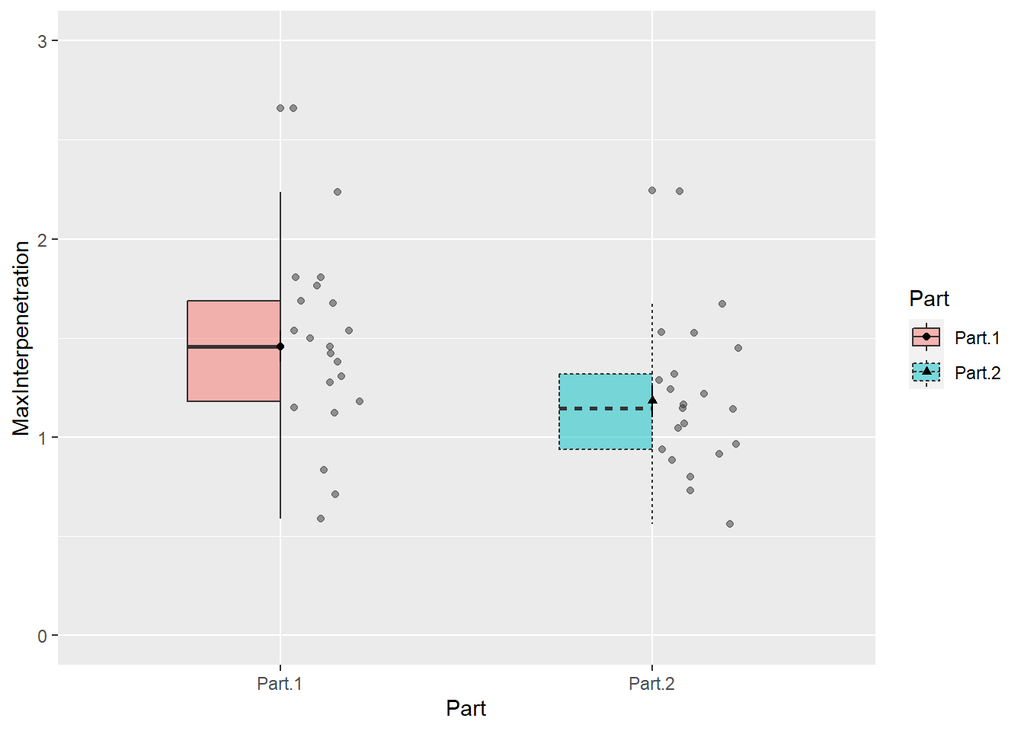

```r
afex_plot(aMaxPlots, x = "Part", error = "within",
                mapping = c("linetype", "shape", "fill"),
                data_geom = ggpol::geom_boxjitter,
                data_arg = list(width = 0.5))  +
            ylim(0, 3)
```

```
## NOTE: Results may be misleading due to involvement in interactions
```

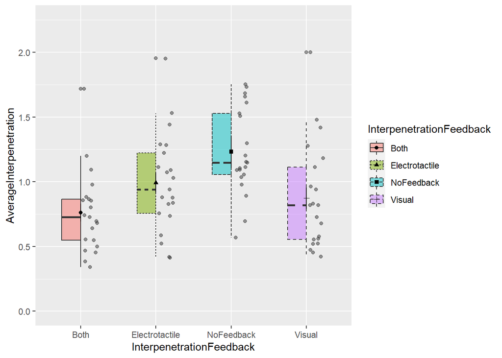

```r
afex_plot(aAvPlots, x = "InterpenetrationFeedback", error = "within",
                mapping = c("linetype", "shape", "fill"),
                data_geom = ggpol::geom_boxjitter,
                data_arg = list(width = 0.5)) +
            ylim(0, 2.25)
```

```
## NOTE: Results may be misleading due to involvement in interactions
```

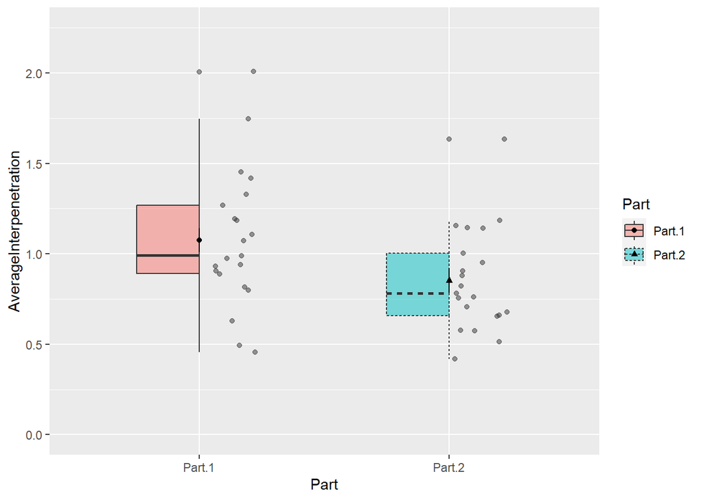

```r
afex_plot(aAvPlots, x = "Part", error = "within",
                mapping = c("linetype", "shape", "fill"),
                data_geom = ggpol::geom_boxjitter,
                data_arg = list(width = 0.5))  +
            ylim(0, 2.25)
```

Let’s plot the main interaction effects (Interpenetration Feedback AND Part of the experiment).

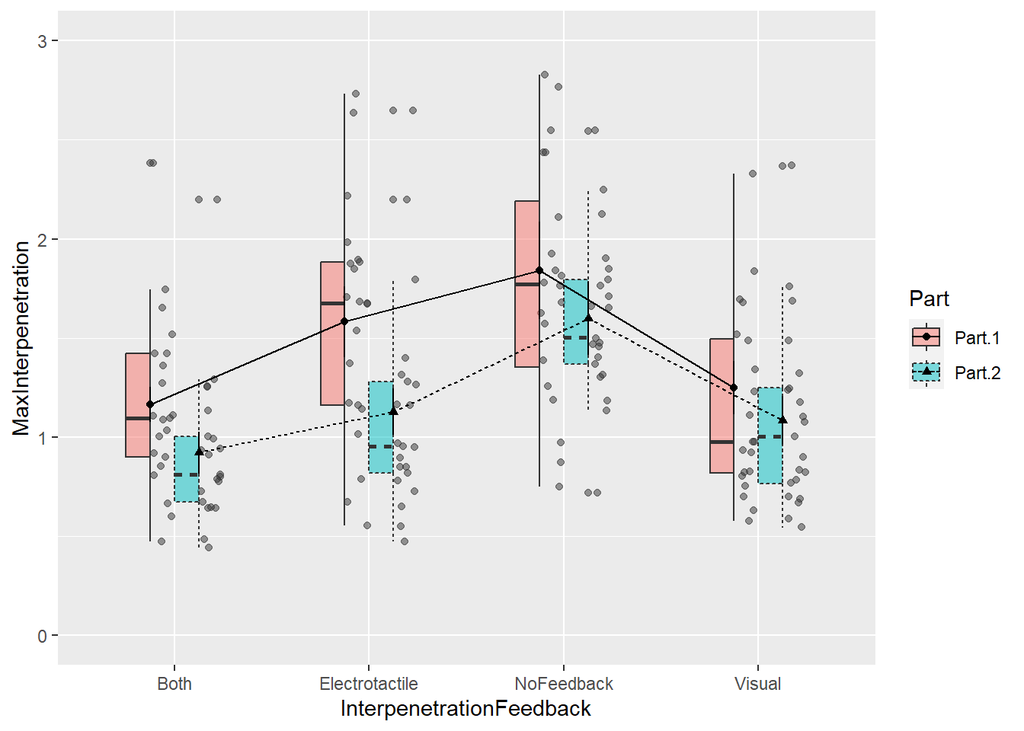

```r
afex_plot(aMaxPlots, x = "InterpenetrationFeedback", trace = "Part", error = "within",
                mapping = c("linetype", "shape", "fill"),
                data_geom = ggpol::geom_boxjitter,
                data_arg = list(width = 0.5)) +
            ylim(0, 3)
```

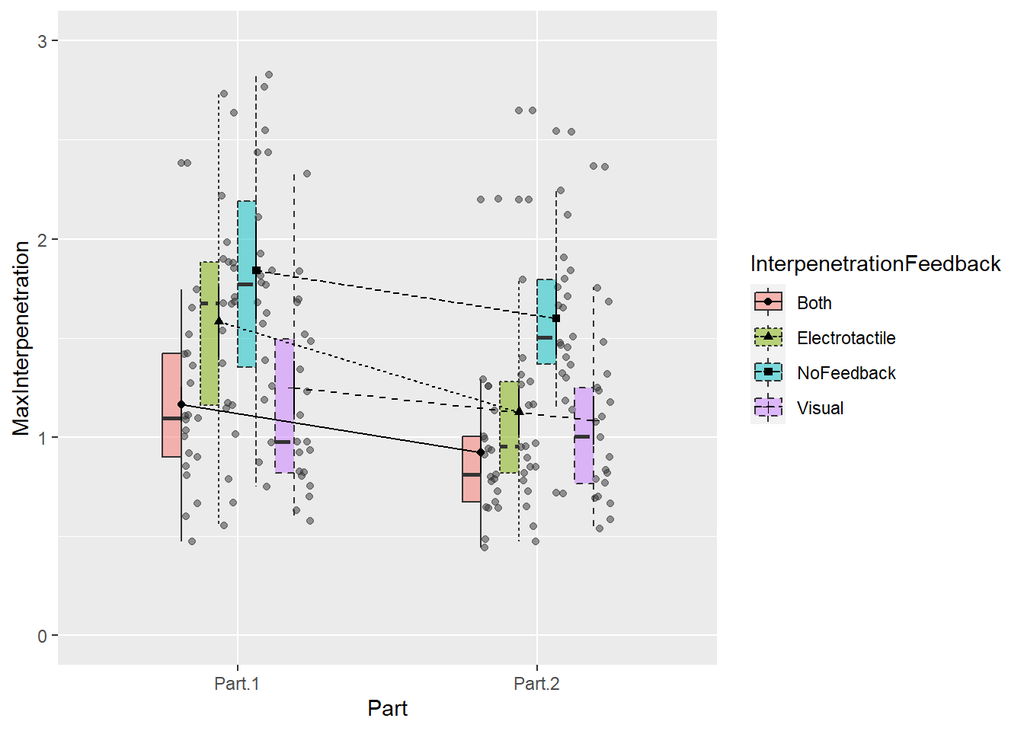

```r
afex_plot(aMaxPlots, x = "Part", trace = "InterpenetrationFeedback", error = "within",
                mapping = c("linetype", "shape", "fill"),
                data_geom = ggpol::geom_boxjitter,
                data_arg = list(width = 0.5))  +
            ylim(0, 3)
```

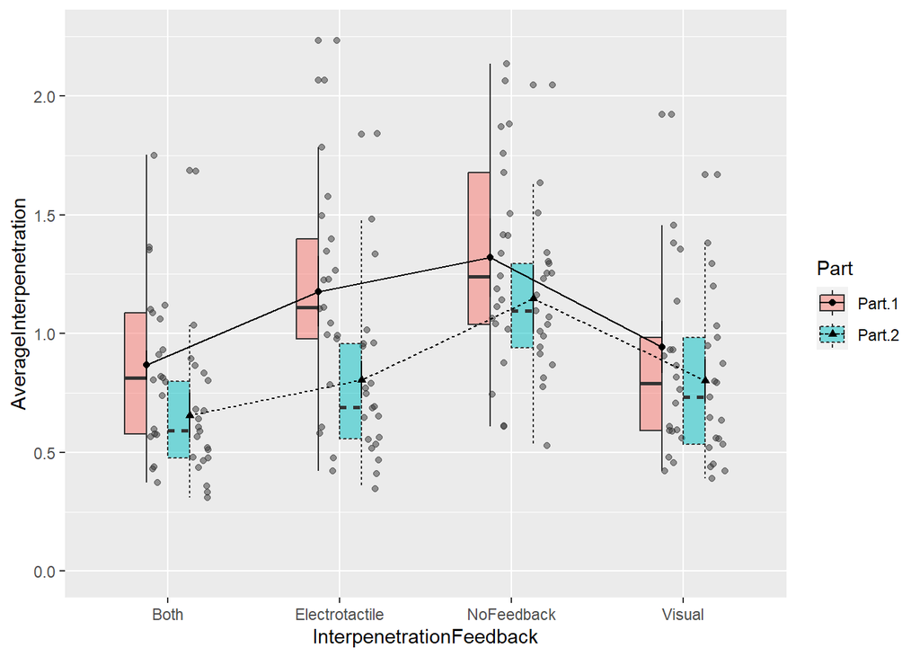

```r
afex_plot(aAvPlots, x = "InterpenetrationFeedback",  trace = "Part", error = "within",
                mapping = c("linetype", "shape", "fill"),
                data_geom = ggpol::geom_boxjitter,
                data_arg = list(width = 0.5)) +
            ylim(0, 2.25)
```

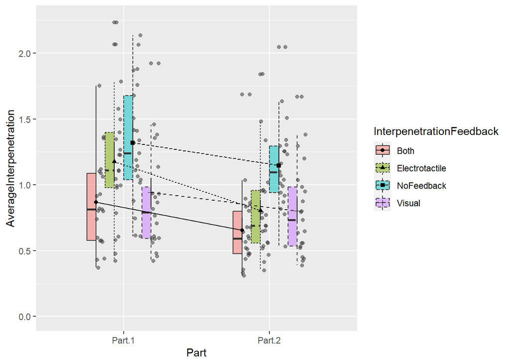

```r
afex_plot(aAvPlots, x = "Part", trace = "InterpenetrationFeedback", error = "within",
                mapping = c("linetype", "shape", "fill"),
                data_geom = ggpol:: geom_boxjitter,
                data_arg = list(width = 0.5))  +
            ylim(0, 2.25)
```

Post-hoc Tests

```r
################################# Maximum Interpenetration #######################
aMaxemm <- emmeans(aMax,~ Part:InterpenetrationFeedback,
 method="pairwise", interaction=TRUE)

pairs(aMaxemm)
```

```
##  contrast                                      estimate     SE   df t.ratio
##  Part.1 Both - Part.2 Both                       0.2322 0.0576 69.6  4.030
##  Part.1 Both - Part.1 Electrotactile            -0.2972 0.0701 98.0 -4.242
##  Part.1 Both - Part.2 Electrotactile             0.0551 0.0751 99.4  0.734
##  Part.1 Both - Part.1 NoFeedback                -0.4568 0.0701 98.0 -6.521
##  Part.1 Both - Part.2 NoFeedback                -0.3508 0.0751 99.4 -4.669
##  Part.1 Both - Part.1 Visual                    -0.0381 0.0701 98.0 -0.543
##  Part.1 Both - Part.2 Visual                     0.0788 0.0751 99.4  1.049
##  Part.2 Both - Part.1 Electrotactile            -0.5293 0.0751 99.4 -7.044
##  Part.2 Both - Part.2 Electrotactile            -0.1770 0.0701 98.0 -2.527
##  Part.2 Both - Part.1 NoFeedback                -0.6890 0.0751 99.4 -9.169
##  Part.2 Both - Part.2 NoFeedback                -0.5830 0.0701 98.0 -8.322
##  Part.2 Both - Part.1 Visual                    -0.2702 0.0751 99.4 -3.596
##  Part.2 Both - Part.2 Visual                    -0.1534 0.0701 98.0 -2.189
##  Part.1 Electrotactile - Part.2 Electrotactile   0.3523 0.0576 69.6  6.115
##  Part.1 Electrotactile - Part.1 NoFeedback      -0.1596 0.0701 98.0 -2.279
##  Part.1 Electrotactile - Part.2 NoFeedback      -0.0537 0.0751 99.4 -0.714
##  Part.1 Electrotactile - Part.1 Visual           0.2591 0.0701 98.0  3.698
##  Part.1 Electrotactile - Part.2 Visual           0.3760 0.0751 99.4  5.003
##  Part.2 Electrotactile - Part.1 NoFeedback      -0.5119 0.0751 99.4 -6.813
##  Part.2 Electrotactile - Part.2 NoFeedback      -0.4060 0.0701 98.0 -5.795
##  Part.2 Electrotactile - Part.1 Visual          -0.0932 0.0751 99.4 -1.240
##  Part.2 Electrotactile - Part.2 Visual           0.0237 0.0701 98.0  0.338
##  Part.1 NoFeedback - Part.2 NoFeedback           0.1060 0.0576 69.6  1.839
##  Part.1 NoFeedback - Part.1 Visual               0.4187 0.0701 98.0  5.977
##  Part.1 NoFeedback - Part.2 Visual               0.5356 0.0751 99.4  7.128
##  Part.2 NoFeedback - Part.1 Visual               0.3128 0.0751 99.4  4.162
##  Part.2 NoFeedback - Part.2 Visual               0.4296 0.0701 98.0  6.133
##  Part.1 Visual - Part.2 Visual                   0.1169 0.0576 69.6  2.029
##  p.value
##  0.0034
##  0.0013
##  0.9957
##  <.0001
##  0.0002
##  0.9994
##  0.9655
##  <.0001
##  0.1966
##  <.0001
##  <.0001
##  0.0114
##  0.3673
##  <.0001
##  0.3159
##  0.9964
##  0.0083
##  0.0001
##  <.0001
##  <.0001
##  0.9177
##  1.0000
##  0.5960
##  <.0001
##  <.0001
##  0.0017
##  <.0001
##  0.4708
##
## P value adjustment: tukey method for comparing a family of 8 estimates
```

```r
require(esvis)
EffectSizeMax <- hedg_g(ParsiDF,MaxInterpenetration ~ InterpenetrationFeedback + Part, keep_d = FALSE) #Calculates the hedge's g per pair!

EffectSizeMax
```

| InterpenetrationFeedback_ref | Part_ref | InterpenetrationFeedback_foc | Part_foc | hedg_g |
| --- | --- | --- | --- | --- |
| Both | Part 1 | Both | Part 2 | 0.61676553 |
| Both | Part 1 | Electrotactile | Part 1 | -0.72831779 |
| Both | Part 1 | Electrotactile | Part 2 | 0.13462477 |
| Both | Part 1 | NoFeedback | Part 1 | -1.16801037 |
| Both | Part 1 | NoFeedback | Part 2 | -1.04872766 |
| Both | Part 1 | Visual | Part 1 | -0.09096969 |
| Both | Part 1 | Visual | Part 2 | 0.20239743 |
| Both | Part 2 | Both | Part 1 | -0.61676553 |
| Both | Part 2 | Electrotactile | Part 1 | -1.32260609 |
| Both | Part 2 | Electrotactile | Part 2 | -0.44056550 |

[output cut: 46 more lines]

```r
################################# Average Interpenetration #######################
aAvemm <- emmeans(aAv,~ Part:InterpenetrationFeedback,
 method="pairwise", interaction= TRUE)

pairs(aAvemm)
```

```
##  contrast                                      estimate     SE   df t.ratio
##  Part.1 Both - Part.2 Both                      0.28574 0.0608 66.2  4.698
##  Part.1 Both - Part.1 Electrotactile           -0.29512 0.0721 97.8 -4.095
##  Part.1 Both - Part.2 Electrotactile            0.08345 0.0786 97.7  1.062
##  Part.1 Both - Part.1 NoFeedback               -0.43712 0.0721 97.8 -6.066
##  Part.1 Both - Part.2 NoFeedback               -0.31874 0.0786 97.7 -4.058
##  Part.1 Both - Part.1 Visual                   -0.04879 0.0721 97.8 -0.677
##  Part.1 Both - Part.2 Visual                    0.08604 0.0786 97.7  1.095
##  Part.2 Both - Part.1 Electrotactile           -0.58085 0.0786 97.7 -7.395
##  Part.2 Both - Part.2 Electrotactile           -0.20229 0.0721 97.8 -2.807
##  Part.2 Both - Part.1 NoFeedback               -0.72285 0.0786 97.7 -9.202
##  Part.2 Both - Part.2 NoFeedback               -0.60448 0.0721 97.8 -8.388
##  Part.2 Both - Part.1 Visual                   -0.33452 0.0786 97.7 -4.259
##  Part.2 Both - Part.2 Visual                   -0.19970 0.0721 97.8 -2.771
##  Part.1 Electrotactile - Part.2 Electrotactile  0.37856 0.0608 66.2  6.225
##  Part.1 Electrotactile - Part.1 NoFeedback     -0.14200 0.0721 97.8 -1.970
##  Part.1 Electrotactile - Part.2 NoFeedback     -0.02363 0.0786 97.7 -0.301
##  Part.1 Electrotactile - Part.1 Visual          0.24633 0.0721 97.8  3.418
##  Part.1 Electrotactile - Part.2 Visual          0.38115 0.0786 97.7  4.852
##  Part.2 Electrotactile - Part.1 NoFeedback     -0.52056 0.0786 97.7 -6.627
##  Part.2 Electrotactile - Part.2 NoFeedback     -0.40219 0.0721 97.8 -5.581
##  Part.2 Electrotactile - Part.1 Visual         -0.13223 0.0786 97.7 -1.683
##  Part.2 Electrotactile - Part.2 Visual          0.00259 0.0721 97.8  0.036
##  Part.1 NoFeedback - Part.2 NoFeedback          0.11838 0.0608 66.2  1.946
##  Part.1 NoFeedback - Part.1 Visual              0.38833 0.0721 97.8  5.389
##  Part.1 NoFeedback - Part.2 Visual              0.52315 0.0786 97.7  6.660
##  Part.2 NoFeedback - Part.1 Visual              0.26995 0.0786 97.7  3.437
##  Part.2 NoFeedback - Part.2 Visual              0.40478 0.0721 97.8  5.617
##  Part.1 Visual - Part.2 Visual                  0.13482 0.0608 66.2  2.217
##  p.value
##  0.0004
##  0.0021
##  0.9630
##  <.0001
##  0.0025
##  0.9974
##  0.9564
##  <.0001
##  0.1051
##  <.0001
##  <.0001
##  0.0012
##  0.1145
##  <.0001
##  0.5069
##  1.0000
##  0.0199
##  0.0001
##  <.0001
##  <.0001
##  0.6978
##  1.0000
##  0.5250
##  <.0001
##  <.0001
##  0.0189
##  <.0001
##  0.3554
##
## P value adjustment: tukey method for comparing a family of 8 estimates
```

```r
EffectSizeAv <- hedg_g(ParsiDF,AverageInterpenetration ~ InterpenetrationFeedback + Part, keep_d = FALSE)
EffectSizeAv
```

| InterpenetrationFeedback_ref | Part_ref | InterpenetrationFeedback_foc | Part_foc | hedg_g |
| --- | --- | --- | --- | --- |
| Both | Part 1 | Both | Part 2 | 0.688559174 |
| Both | Part 1 | Electrotactile | Part 1 | -0.673535198 |
| Both | Part 1 | Electrotactile | Part 2 | 0.197330057 |
| Both | Part 1 | NoFeedback | Part 1 | -1.102751598 |
| Both | Part 1 | NoFeedback | Part 2 | -0.881538433 |
| Both | Part 1 | Visual | Part 1 | -0.108174394 |
| Both | Part 1 | Visual | Part 2 | 0.202557636 |
| Both | Part 2 | Both | Part 1 | -0.688559174 |
| Both | Part 2 | Electrotactile | Part 1 | -1.334866235 |
| Both | Part 2 | Electrotactile | Part 2 | -0.481928627 |

[output cut: 46 more lines]

```r
############ Change in the Performance (Part 1 vs Part2) per Interpenetration Feedback #############

contrast(emmeans(aMax,~ Part:InterpenetrationFeedback),
         method="pairwise", interaction=TRUE)
```

```
##  Part_pairwise   InterpenetrationFeedback_pairwise estimate     SE df t.ratio
##  Part.1 - Part.2 Both - Electrotactile              -0.1201 0.0718 60 -1.672
##  Part.1 - Part.2 Both - NoFeedback                   0.1262 0.0718 60  1.757
##  Part.1 - Part.2 Both - Visual                       0.1153 0.0718 60  1.605
##  Part.1 - Part.2 Electrotactile - NoFeedback         0.2463 0.0718 60  3.429
##  Part.1 - Part.2 Electrotactile - Visual             0.2354 0.0718 60  3.277
##  Part.1 - Part.2 NoFeedback - Visual                -0.0109 0.0718 60 -0.152
##  p.value
##  0.0997
##  0.0841
##  0.1137
##  0.0011
##  0.0017
##  0.8800
```

```r
contrast(emmeans(aAv,~ Part:InterpenetrationFeedback),
         method="pairwise", interaction=TRUE)
```

```
##  Part_pairwise   InterpenetrationFeedback_pairwise estimate     SE df t.ratio
##  Part.1 - Part.2 Both - Electrotactile              -0.0928 0.0738 60 -1.258
##  Part.1 - Part.2 Both - NoFeedback                   0.1674 0.0738 60  2.268
##  Part.1 - Part.2 Both - Visual                       0.1509 0.0738 60  2.046
##  Part.1 - Part.2 Electrotactile - NoFeedback         0.2602 0.0738 60  3.527
##  Part.1 - Part.2 Electrotactile - Visual             0.2437 0.0738 60  3.304
##  Part.1 - Part.2 NoFeedback - Visual                -0.0164 0.0738 60 -0.223
##  p.value
##  0.2132
##  0.0269
##  0.0452
##  0.0008
##  0.0016
##  0.8243
```

Hedge’s G Interpretation:

Small effect (cannot be discerned by the naked eye) = 0.2

Medium Effect = 0.5

Large Effect (can be seen by the naked eye) = 0.8

Regarding the change of the performance for each type of interpenetration feedback between part 1 and part 2 of the experiment!

we can see that for MAX INTERPENETRATION the significant comparisons are:

1. Part.1 - Part.2 Electrotactile - NoFeedback p value = 0.0011
2. Part.1 - Part.2 Electrotactile - Visual p value = 0.0017

This means that the improvement of the performance from part 1 to part 2 regarding the maximum interpenetration was significantly greater for the “Electrotactile Feedback” compared to the “No Feedback” and “Visual Feedback” respectively! The rest of the comparisons were insignificant!

For the AVERAGE INTERPENETRATION the significant comparisons are:

1. Part.1 - Part.2 Both - NoFeedback p value = 0.0269
2. Part.1 - Part.2 Both - Visual p value = 0.0452
3. Part.1 - Part.2 Electrotactile - NoFeedback p value = 0.0008
4. Part.1 - Part.2 Electrotactile - Visual p value = 0.0016

This means that the improvement of the performance from part 1 to part 2 regarding the average interpenetration was significantly greater for the “Electrotactile Feedback” compared to the “No Feedback” and “Visual Feedback” respectively!

Also, that the improvement of the performance from part 1 to part 2 regarding the average interpenetration was significantly greater for the “Combined (i.e., Both) Feedback” compared to the “No Feedback” and “Visual Feedback” respectively! The rest of the comparisons were insignificant!